# Data Visualization using ggplot

Alice Kamau| Ken Mwai | Mark Otiende

6/5/2021

# Learning objectives

- Produce boxplots, scatter plots and smoothed plots using ggplot.
- Describe what faceting is and apply faceting in ggplot.
- Modify the aesthetics of an existing ggplot plot (including axis labels and color).
- Build complex and customized plots from data in a data frame.

# Building your plots iteratively

```r
library(tidyverse)
```

- Set the directory

```r
setwd("~")
```

- Load the data

```r
bw_df <- read.csv("Data/birthweight2.csv")
names(bw_df)
```

```
##  [1] "id"      "matage"  "ht"      "gestwks" "sex"     "bweight"
##  [7] "ethnic"  "lbw"     "agegrp"  "lbw2"    "agegrp1"
```

# Boxplot - for a categorical and continuous variable

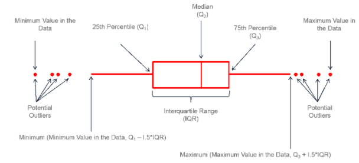

# Lets do a Box plot?

- A box plot of bweight vs sex

[figure not shown]

```r
ggplot(data = bw_df)
```

# Adding aesthetics and labels

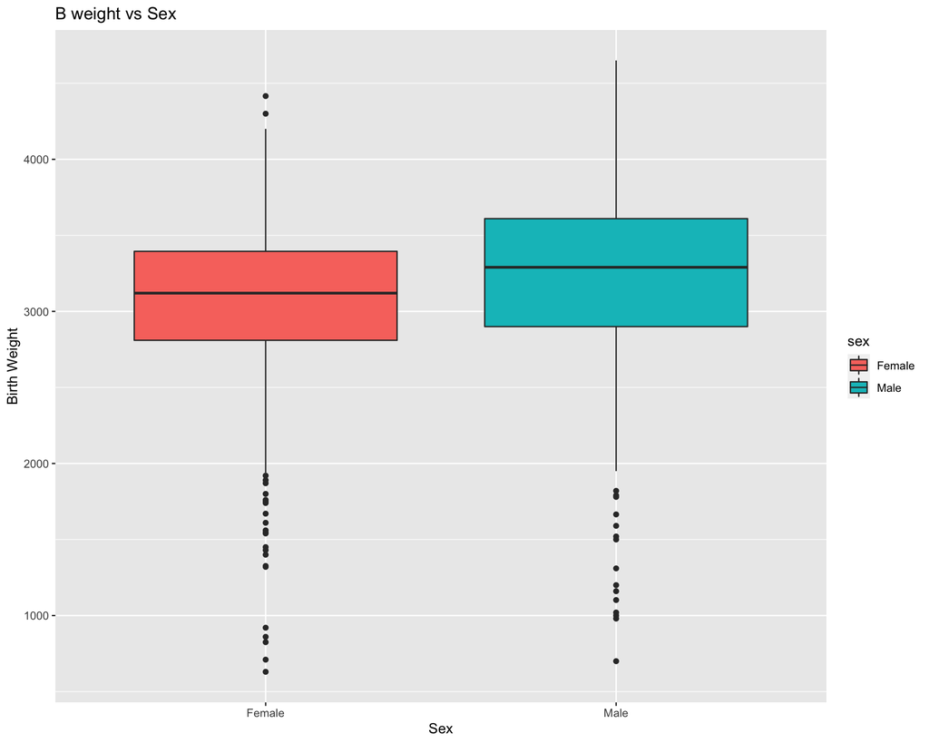

```r
ggplot(data = bw_df) + geom_boxplot(aes(y = bweight, x = sex,
    fill = sex)) + ylab("Birth Weight") + xlab("Sex") + ggtitle("B weight vs Sex")
```

# Box plot and add scatter

- By adding points to the boxplot, we can have a better idea of the number of measurements and of their distribution:

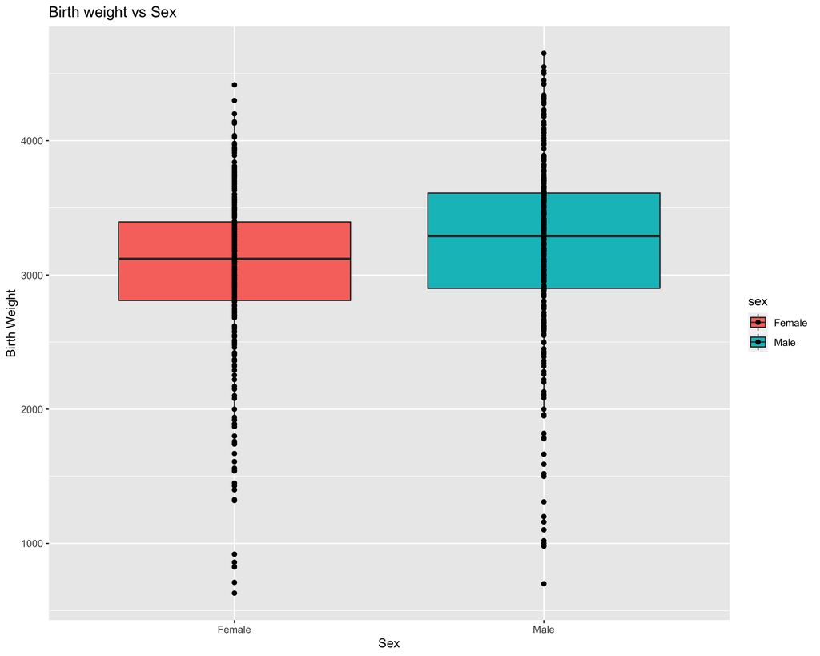

```r
ggplot(data = bw_df, mapping = aes(y = bweight, x = sex, fill = sex)) +
    geom_boxplot() + geom_point() + ylab("Birth Weight") + xlab("Sex") +
    ggtitle("Birth weight vs Sex")
```

# Box plot and add scatter points that are jittered

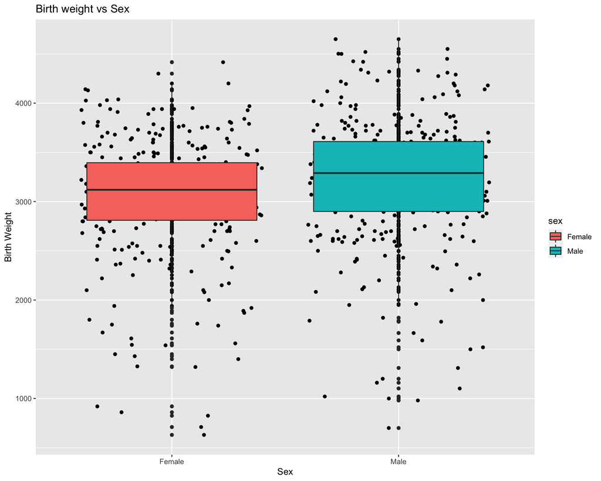

```r
ggplot(data = bw_df, mapping = aes(y = bweight, x = sex, fill = sex)) +
    geom_point() + geom_jitter() + geom_boxplot() + ylab("Birth Weight") +
    xlab("Sex") + ggtitle("Birth weight vs Sex")
```

- Boxplots are useful summaries, but hide the shape of the distribution.
- For example, if there is a bimodal distribution, it would not be observed with a boxplot.
- An alternative to the boxplot is the violin plot (sometimes known as a beanplot), where the shape (of the density of points) is drawn.
- Replace the box plot with a violin plot; see geom_violin().

# Violin plot

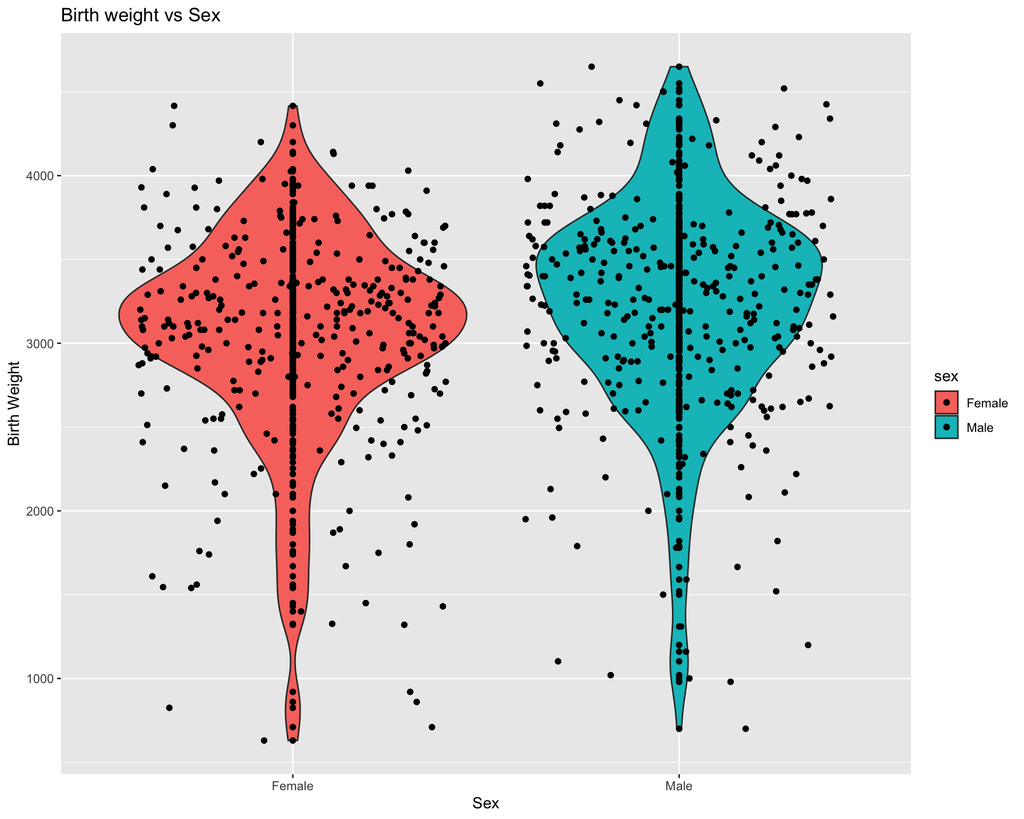

```r
ggplot(data = bw_df, mapping = aes(y = bweight, x = sex, fill = sex)) +
    geom_violin() + geom_point() + geom_jitter() + ylab("Birth Weight") +
    xlab("Sex") + ggtitle("Birth weight vs Sex")
```

# Scatter plot with ggplot2 - for two continuous variables

- We can build a plot sequentially to see how each grammatical layer changes the appearance
- Start with data and aesthetics

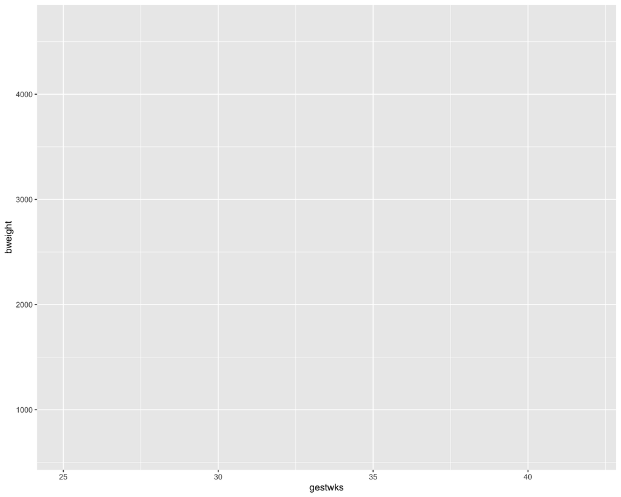

```r
# Start with data and aesthetics
ggplot(data = bw_df, mapping = aes(x = gestwks, y = bweight,
    color = sex))
```

# Add a point geom

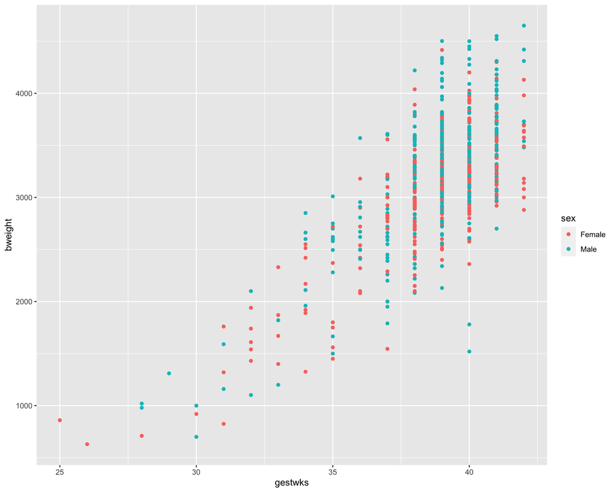

```r
# Start with data and aesthetics
ggplot(data = bw_df, mapping = aes(x = gestwks, y = bweight,
    color = sex)) + # Add a point geom
geom_point()
```

# Add a smooth geom

- To add a regression line on a scatter plot, use the function geom_smooth()

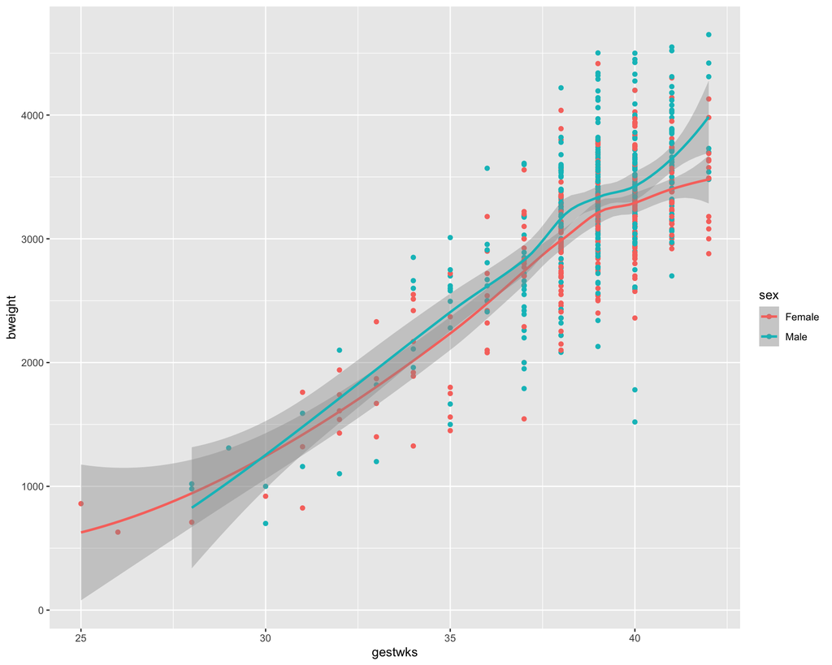

```r
# Start with data and aesthetics
ggplot(data = bw_df, mapping = aes(x = gestwks, y = bweight,
    color = sex)) + # Add a point geom
geom_point() + ## Add a smooth geom
geom_smooth()
```

# Make the smooth geom straight

- geom_smooth() is used in combination with the argument method = lm. lm stands for linear model.

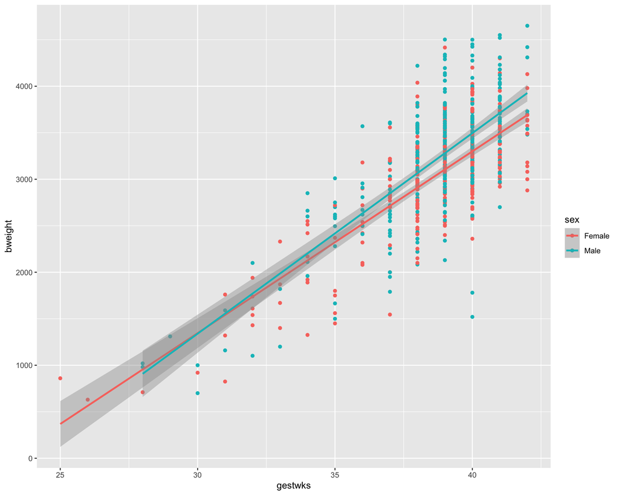

```r
# Start with data and aesthetics
ggplot(data = bw_df, mapping = aes(x = gestwks, y = bweight,
    color = sex)) + # Add a point geom
geom_point() + ## Add a smooth geom geom_smooth() + Make it straight
geom_smooth(method = "lm")
```

# Faceting

- ggplot has a special technique called faceting that allows the user to split one plot into multiple plots based on a factor included in the dataset.
- We will use it to make a scatter plot of birth weight vs gestwks stratified by gender:
- Now we would like to split each plot by the sex of each individual measured.
- You can also organise the panels only by columns (or only by rows):

# Facet by sex

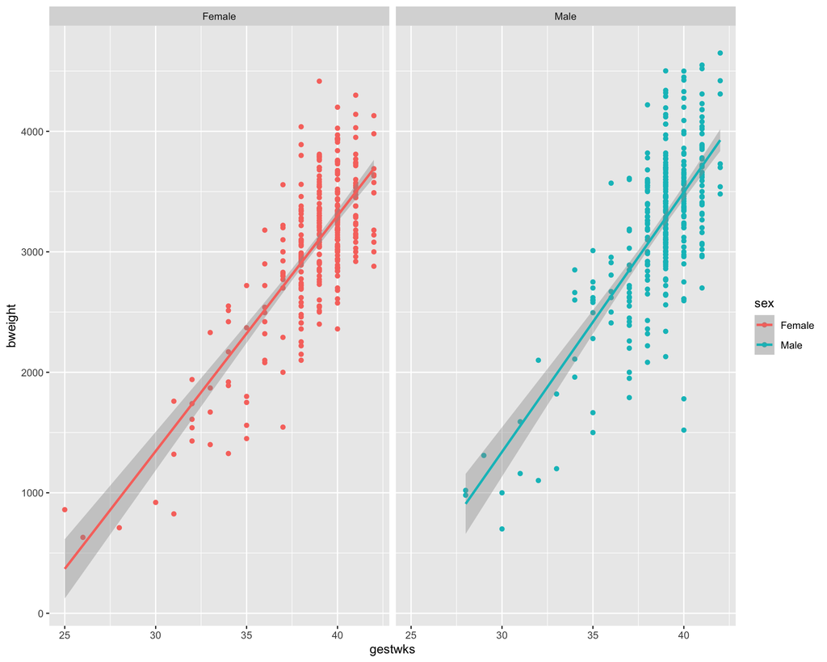

```r
# Start with data and aesthetics
ggplot(data = bw_df, mapping = aes(x = gestwks, y = bweight,
    color = sex)) + # Add a point geom
geom_point() + ## Add a smooth geom geom_smooth() + Make it straight
geom_smooth(method = "lm") + # Facet by sex
facet_wrap(vars(sex), ncol = 2)
```

# add labels

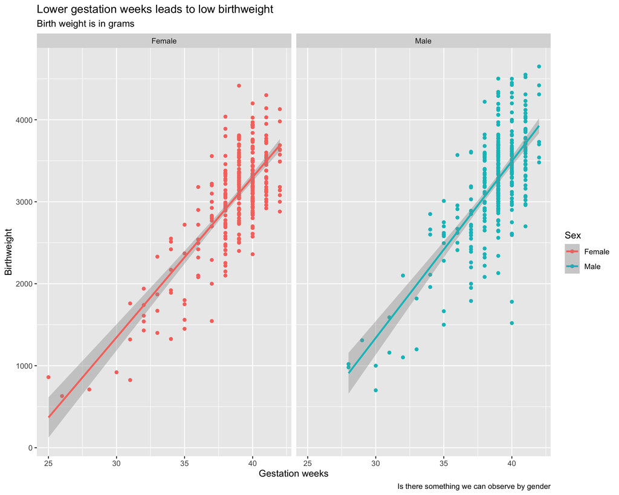

```r
# Start with data and aesthetics
ggplot(data = bw_df, mapping = aes(x = gestwks, y = bweight,
    color = sex)) + # Add a point geom
geom_point() + ## Add a smooth geom geom_smooth() + Make it straight
geom_smooth(method = "lm") + # Facet by sex
facet_wrap(vars(sex), ncol = 2) + ## add labels
labs(x = "Gestation weeks", y = "Birthweight", color = "Sex",
    title = "Lower gestation weeks leads to low birthweight",
    subtitle = "Birth weight is in grams", caption = "Is there something we can observe by gender")
```

# adding ggplot2 themes

[figure not shown]

# Exporting plots

```r
my_plot2 <- ggplot(data = bw_df, mapping = aes(x = gestwks, y = bweight,
    color = sex)) + geom_point() + geom_smooth(method = "lm") +
    facet_wrap(vars(sex), ncol = 2) + labs(x = "Gestation weeks",
    y = "Birthweight", color = "Sex", title = "Lower gestation weeks leads to low birthweight",
    subtitle = "Birth weight is in grams", caption = "Is there something we can observe by gender") +
    theme_bw() + theme(plot.title = element_text(size = 15, face = "bold"),
    axis.text.x = element_text(size = 8), axis.text.y = element_text(size = 8),
    axis.title.x = element_text(size = 10), axis.title.y = element_text(size = 10)) +
    scale_color_discrete(name = "Sex")
ggsave("Output/Bweight.pdf", my_plot2, width = 15, height = 10)
```

# Useful link and resource with examples and code

https://www.data-to-viz.com/

# Break out session - Exercises

- Replicate the plot below and save

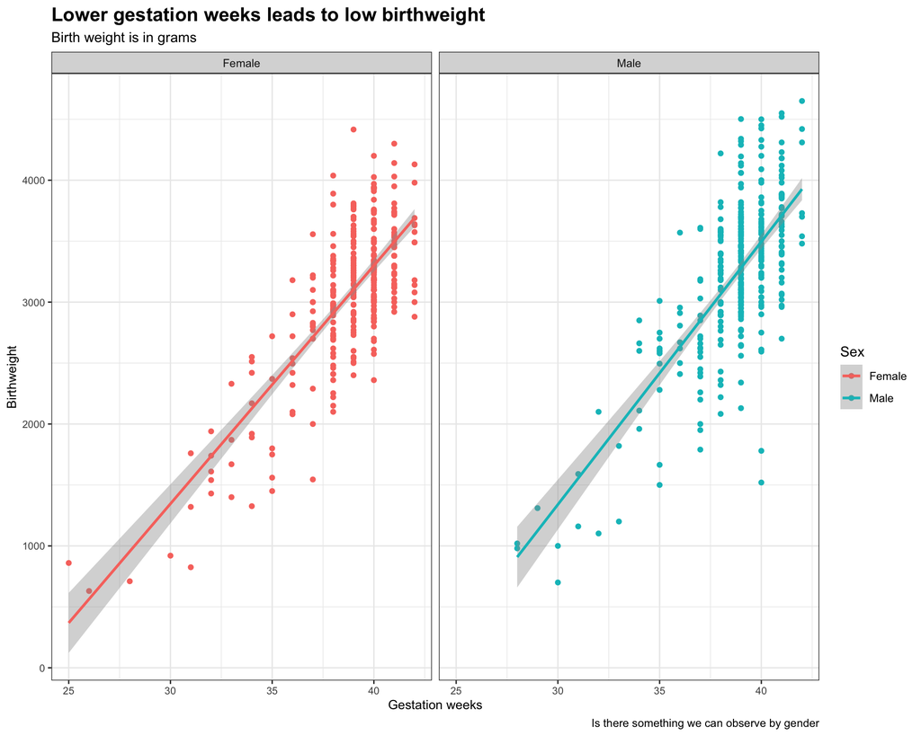

```r
ggplot(data = bw_df, mapping = aes(x = gestwks, y = bweight,
    color = sex)) + geom_point() + geom_smooth(method = "lm") +
    facet_wrap(vars(sex), ncol = 2) + labs(x = "Gestation weeks",
    y = "Birthweight", color = "Sex", title = "Lower gestation weeks leads to low birthweight",
    subtitle = "Birth weight is in grams", caption = "Is there something we can observe by gender") +
    theme_bw() + theme(plot.title = element_text(size = 15, face = "bold"),
    axis.text.x = element_text(size = 8), axis.text.y = element_text(size = 8),
    axis.title.x = element_text(size = 10), axis.title.y = element_text(size = 10)) +
    scale_color_discrete(name = "Sex")
```

- Can you make the shape of the points in the scatter plot to vary with ethnicity?
- add a scale shape attribute. Hint use: scale_shape_discrete(name=“legend title”)
- Instead of having multiple smoothing lines for each ethnic group, integrate them all under one line.

# Solution

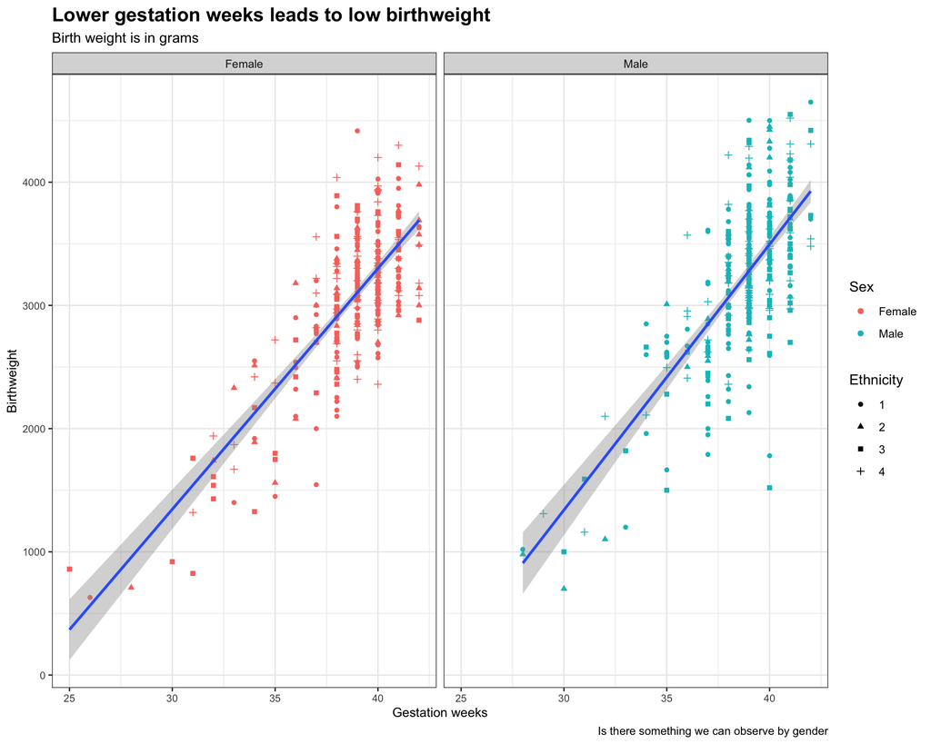